# ‘gapminder’ Data Visualization - Shiny application & Reproducible Pitch Presentation

Developing Data Products Course Project held on *coursera.org

Maroje Raguž

19th May 2021

# Introduction

Package ‘gapminder’ provides values for life expectancy, GDP per capita, and population for 142 countries @ five years intervals in the period from 1952 to 2007.

```r
library(gapminder)
str(gapminder)
```

```
## tibble [1,704 x 6] (S3: tbl_df/tbl/data.frame)
##  $ country  : Factor w/ 142 levels "Afghanistan",..: 1 1 1 1 1 1 1 1 1 1 ...
##  $ continent: Factor w/ 5 levels "Africa","Americas",..: 3 3 3 3 3 3 3 3 3 3 ...
##  $ year     : int [1:1704] 1952 1957 1962 1967 1972 1977 1982 1987 1992 1997 ...
##  $ lifeExp  : num [1:1704] 28.8 30.3 32 34 36.1 ...
##  $ pop      : int [1:1704] 8425333 9240934 10267083 11537966 13079460 14880372 12881816 13867957 16317921 22227415 ...
##  $ gdpPercap: num [1:1704] 779 821 853 836 740 ...
```

This course project application visualize positive correlation between duration of life expectancy & GDP per capita for each of 142 countries.

The presentation is generated with RStudio as a part of the Developing Data Products Course Project held on *coursera.org*

The Shiny application pitched by this presentation can be found @ https://mrshiny13.shinyapps.io/DDP_Course_Project_Shiny_Application/

The Shiny app source code is available @ https://github.com/MRHub13/Developing-Data-Products

# Application Overview

- application is written in Shiny - a web application framework for R
- source code consists of two files, *server.R* & *ui.R*
  - *server.R* covers the Shiny web application server logic
  - *ui.R* includes the the user-interface definition
- application is hosted @ Rstudio’s Shiny server in the cloud (*shinyapps.io*)

# 1. Left Panel of the Application

- **Title** labeled by default but user can modify the title
- **Point size** a user can change the size of plot points
- **Add best fiting (LM) line** can be applied
- **Point color** different plot color can be selected
- **Continent** & **Country** can be filtered
- **Life expectancy** interval can be selected on slieder
- user can download filtered data by using a **Download** button

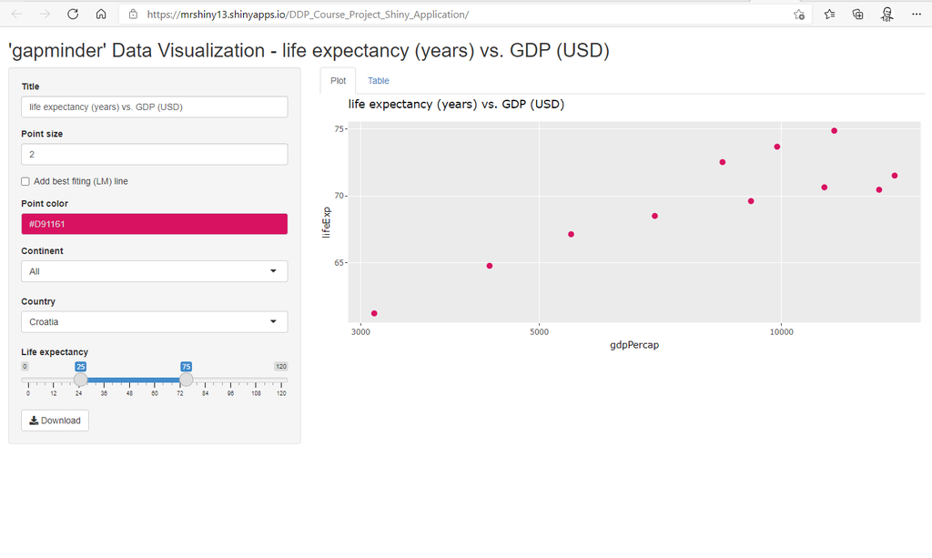

# 2. Main Panel of the Application:

There are two tabs @ the main panel:

- *Plot* - displays plot for corresponding dataframe
- *Table* - displays a searchable-interactive table for corresponding dataframe

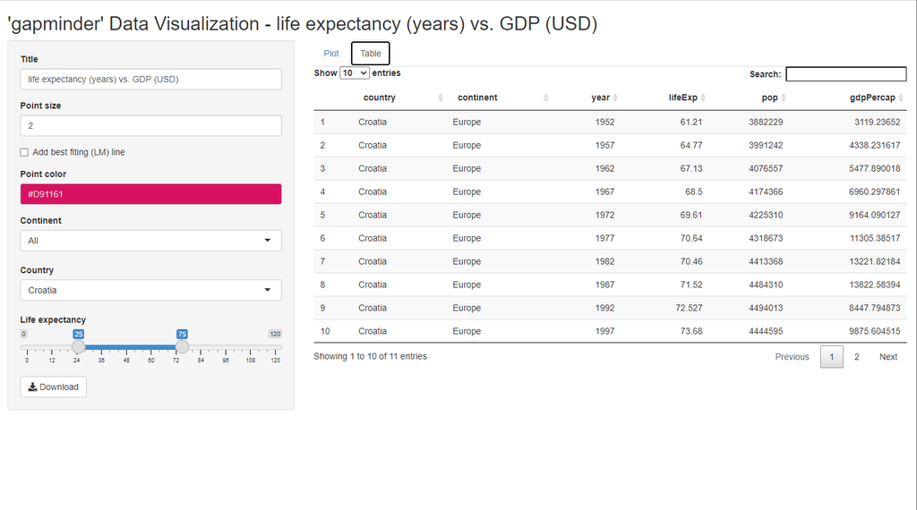